# Lidiando con outliers

### Introducción

Los outliers son los valores extremos que tiene una variable, dependiendo del modelo o requerimiento, puede ser necesario tratarlos ya sea transformando o eliminandolos.

### Distribución variable “Income”

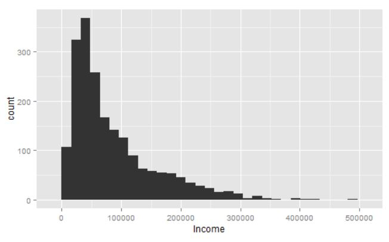

Ésta será la variable ejemplo, la cual representa los ingresos en $ de clientes de una empresa. Observamos como hay pocos valores con valores altos, y muchos con valores bajos.

#### Si elegimos eliminarlos…

Una pregunta común es *¿cuántos casos excluir?* podemos elegir dejar afuera el 1% de los valores mas altos, con lo cual tendríamos:

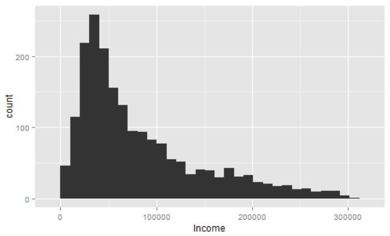

La distribución se ve muy similar, ahora llega hasta 300.000 en vez de 500.000.

Si hacemos este proceso **iterativamente** -sacando el 1% mas grande, y a ese resultado se le vuelve a sacar el 1%, y asi sucesivamente por un total de 10 veces- estaremos analizando distintos valores de punto. Sucede algo curioso con el resultado, **la silutea se mantiene siempre parecida** a:

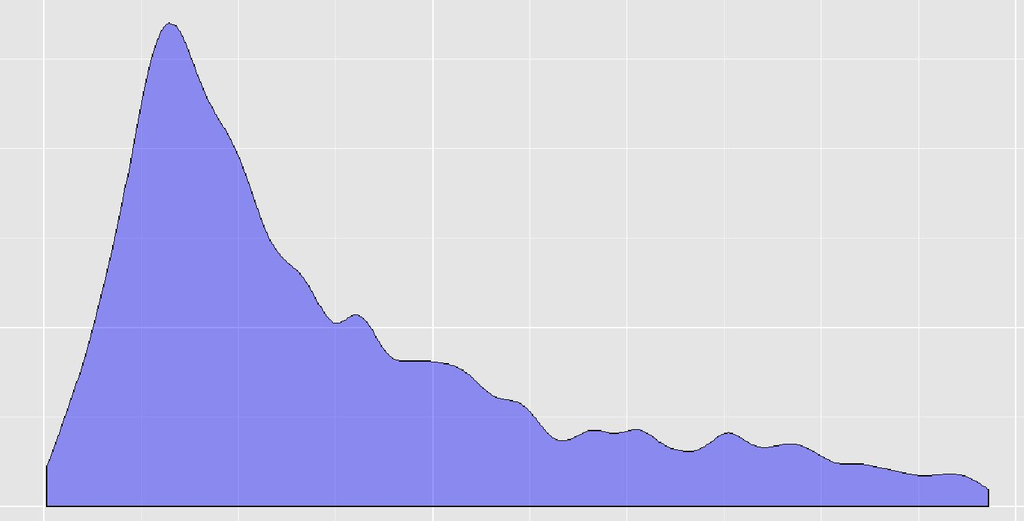

#### Animando el ejemplo

La siguente animación muestra en acción el proceso iterativo de eliminación: como a medida que se va dejando afuera el 1% mas grande, la silueta mantiene un aspecto similar:

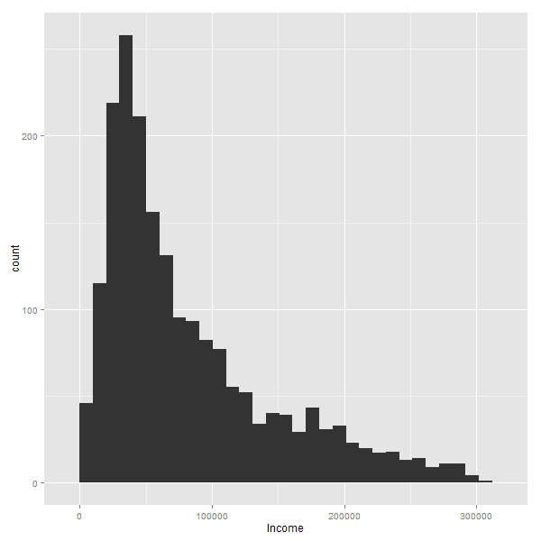

Es decir, siempre habran muchas personas con ingresos bajos/medios, y pocos con ingresos altos. Lo que naturalmente cambian, son los valores de los ejes.

Si cambiamos el gráfico histograma por uno de **densidad**, el efecto que aparece es mas parecido a un *zoom* hacia la parte izquierda de los datos:

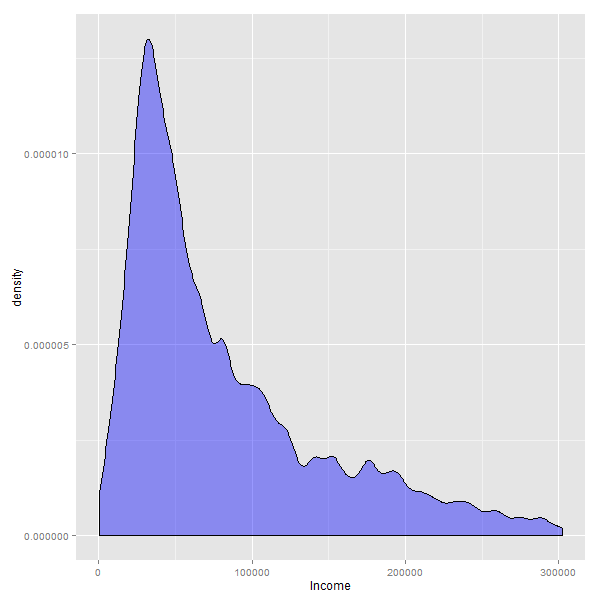

**Cuando se eliminan los valores mas bajos, o mas altos de una variable, lo que se consigue es hacer un acercamiento -ó “zoom”- hacia donde se encuentra la mayor cantidad de casos.**

#### Reflexión final

En este caso en particular se podría dejar afuera el 0.5 o 1% de los datos. Aunque no siempre es recomendable eliminar outliers, a veces pueden representar fraudes, un desperfecto en una máquina, u otro evento que merece una inspección mayor.

#### Contacto

Código disponible en [github](https://github.com/pablo14/outliers_treatment)

Temas de outliers y tratamiento de datos se ven en el **curso e-learning: [Data Science with R](http://datascienceheroes.com/learning.html)** (solicitar demo gratuita en info@datascienceheroes.com)